# burden_analyses_lmm_publication_clean

Sigurgeir Olafsson

11/3/2019

## Burden of somatic mutation in inflammatory bowel disease

This document describes statistical analyses used to test if inflammatory bowel disease (IBD) affects the somatic mutation burden in the colon.

```r
library(ggplot2)
library(cowplot)
library(nlme)
library(lme4)
library(reshape2)
## Read in some data:
########################
crypt_meta <- read.table("/Users/so11/phd/so11_nfs/somatic_ibd_p1/sample_info/crypt_metadata_library_bank.txt", h=T)
patient_meta <- read.table("/Users/so11/phd/so11_nfs/somatic_ibd_p1/sample_info/patient_metaData.txt", h=T)
crypt_meta <- subset(crypt_meta, WGS_status=="WGS")

mutCount <- read.table("/Users/so11/phd/so11_lustre/somatic_ibd_p1/phylogenics/MPBoot/snv/adj_mutCounts/combined_truncBinom_adjusted.txt", h=T)
colnames(mutCount) <- c("crypt_ID", "adj_snv")

mutCount_unadj <- read.table("/Users/so11/phd/so11_lustre/somatic_ibd_p1/qc/binomial_filters/combined_Unadj_MutCount.txt", h=T)
mutCount_unadj$crypt_ID <- gsub("_VAF", "", mutCount_unadj$crypt_ID)

## We can now merge all the datasets:
crypt_meta <- merge(crypt_meta, mutCount, by="crypt_ID")
crypt_meta <- merge(crypt_meta, mutCount_unadj, by="crypt_ID")
crypt_meta <- merge(crypt_meta, patient_meta, by="patient_ID")

## Remove patient from control cohort that was massive outlier - high mutation burden due to chemotherapy
crypt_meta <- subset(crypt_meta, patient_ID!="O337")

## Need to clean up the crypt_metadata a bit
test_cohort <- crypt_meta
test_cohort <- subset(test_cohort, location!="Ileum" & location!="Terminal_ileum")

## Set disease duration for never inflamed regions as 0
test_cohort$DiseaseDuration <- as.numeric(as.character(test_cohort$DiseaseDuration))
test_cohort$DiseaseDuration[is.na(test_cohort$DiseaseDuration)] <- 0
test_cohort$DiseaseDuration[test_cohort$type=="Never_Inflamed"] <- 0

## Add 0.5 years to disease duration to avoid 0 in this category for newly diagnosed patients.
## This is reasonable as IBD symptoms often start months before diagnosis.
test_cohort$DiseaseDuration[test_cohort$type!="Never_Inflamed"] <- test_cohort$DiseaseDuration[test_cohort$type!="Never_Inflamed"] +0.5

## The IBD dataset has higher spatial resolution than the control dataset. Set the locations as Left, Right and Transverse
test_cohort$location[test_cohort$location %in% c("Ascending", "Cecum", "ICV")] <- "Right"
test_cohort$location[test_cohort$location %in% c("Descending", "Rectum", "Sigmoid")] <- "Left"
test_cohort$location[test_cohort$location %in% c("Hepatic", "Splenic_flexure")] <- "Transverse"

test_cohort$colour <- "#A72608"
test_cohort$colour[test_cohort$cohort=="control_data"] <- "#BFD7EA"
test_cohort$colour[test_cohort$cohort=="ibd_cohort" & test_cohort$type=="Never_Inflamed"] <- "#FCA311"


head(subset(test_cohort, cohort=="ibd_cohort"))
```

```
##     patient_ID crypt_ID SANGER_PLATE_ID WELL SANGER_SAMPLE_ID biopsy_ID
## 231   patient1   P1B1_2       DN516874O   B1   IBD_SOM7378122      P1B1
## 232   patient1   P1B1_3       DN516874O   C1   IBD_SOM7378123      P1B1
## 233   patient1   P1B1_4       DN516874O   D1   IBD_SOM7378124      P1B1
## 234   patient1   P1B1_5       DN516874O   E1   IBD_SOM7378125      P1B1
## 235   patient1   P1B1_6       DN516874O   F1   IBD_SOM7378126      P1B1
## 236   patient1   P1B2_1       DN516874O   A2   IBD_SOM7378129      P1B2
##     lib_conc_.ng.ul. WGS_status neighbors neighbours.1 location     type
## 231           26.108        WGS    P1B1_3         <NA>    Right Inflamed
## 232            7.861        WGS    P1B1_2         <NA>    Right Inflamed
## 233           13.101        WGS      <NA>         <NA>    Right Inflamed
## 234           16.118        WGS    P1B1_6         <NA>    Right Inflamed
## 235           10.111        WGS    P1B1_5         <NA>    Right Inflamed
## 236           31.301        WGS      <NA>         <NA>    Right Inflamed
##     lcm_date Coverage matched_normal excl_criteria projectNr     cohort
```

[output cut: 34 more lines]

```r
head(subset(test_cohort, cohort=="control_data"))
```

```
##   patient_ID     crypt_ID SANGER_PLATE_ID WELL SANGER_SAMPLE_ID biopsy_ID
## 1        300    PD37509b8            <NA> <NA>             <NA> 300_Right
## 2        300    PD37509b9            <NA> <NA>             <NA> 300_Right
## 3        312    PD37510b4            <NA> <NA>             <NA>  312_Left
## 4        312    PD37510b7            <NA> <NA>             <NA>  312_Left
## 5        312    PD37510b8            <NA> <NA>             <NA>  312_Left
## 6        HLS HLS_1C_30_B5            <NA> <NA>             <NA> HLS_Right
##   lib_conc_.ng.ul. WGS_status neighbors neighbours.1 location
## 1               NA        WGS      <NA>         <NA>    Right
## 2               NA        WGS      <NA>         <NA>    Right
## 3               NA        WGS      <NA>         <NA>     Left
## 4               NA        WGS      <NA>         <NA>     Left
## 5               NA        WGS      <NA>         <NA>     Left
## 6               NA        WGS      <NA>         <NA>    Right
##             type lcm_date Coverage matched_normal excl_criteria projectNr
```

[output cut: 34 more lines]

```r
dim(subset(test_cohort, cohort=="ibd_cohort"))
```

```
## [1] 370  36
```

```r
dim(subset(test_cohort, cohort=="control_data"))
```

```
## [1] 412  36
```

```r
length(unique(subset(test_cohort, cohort=="ibd_cohort")$patient_ID))
```

```
## [1] 45
```

```r
length(unique(subset(test_cohort, cohort=="ibd_cohort" & Disease=="CD")$patient_ID))
```

```
## [1] 17
```

```r
length(unique(subset(test_cohort, cohort=="ibd_cohort" & Disease=="UC")$patient_ID))
```

```
## [1] 28
```

```r
length(unique(subset(test_cohort, cohort=="control_data")$patient_ID))
```

```
## [1] 41
```

## Linear mixed effects model for substitution counts

I will use the lme() function of the nlme package to fit a linear mixed effects model to the data. This will account for non-independence of the observations - as crypts are grouped by biopsies, and biopsies are nested within patients.

The components of the model are: 1. Age and location in the bowel are fixed effects of interest, known from Lee-Six et al. (2019) to affect the somatic mutation burden.

### The null model

I want to confirm that there is indeed no effect of coverage or vaf and then decide if there should be an interaction effect for Age and location.

```r
# LME model that allows for different variances for each patient and for each corhot (IBD vs controls)

model_null.lme <- lme(fixed = adj_snv ~ Age + location,
                      random = list(patient_ID = pdSymm(form = ~ cohort - 1), biopsy_ID = pdSymm(form = ~ cohort - 1)),
                      weights = varIdent(form= ~ 1 | cohort),
                      data = test_cohort, method="ML")

summary(model_null.lme)
```

```
## Linear mixed-effects model fit by maximum likelihood
##  Data: test_cohort
##        AIC      BIC    logLik
##   12018.14 12074.09 -5997.072
##
## Random effects:
##  Formula: ~cohort - 1 | patient_ID
##  Structure: General positive-definite
##                    StdDev    Corr
## cohortcontrol_data  609.5353 chrtc_
## cohortibd_cohort   1003.7140 0
##
##  Formula: ~cohort - 1 | biopsy_ID %in% patient_ID
##  Structure: General positive-definite
##                    StdDev    Corr
## cohortcontrol_data  427.3622 chrtc_
## cohortibd_cohort   1066.4868 0
## Residual            337.4163
##
## Variance function:
##  Structure: Different standard deviations per stratum
##  Formula: ~1 | cohort
##  Parameter estimates:
## control_data   ibd_cohort
##     1.000000     1.079109
## Fixed effects: adj_snv ~ Age + location
##                       Value Std.Error  DF  t-value p-value
## (Intercept)        665.9944  362.1267 582 1.839120  0.0664
## Age                 37.0845    6.0973  84 6.082137  0.0000
## locationRight      234.7999  110.2591 112 2.129528  0.0354
## locationTransverse 263.0412  109.5710 582 2.400647  0.0167
##  Correlation:
##                    (Intr) Age    lctnRg
## Age                -0.950
## locationRight      -0.125 -0.033
## locationTransverse -0.064 -0.084  0.513
##
## Standardized Within-Group Residuals:
##        Min         Q1        Med         Q3        Max
## -3.7431436 -0.4656283 -0.0128983  0.3950256  3.6343683
##
## Number of Observations: 782
## Number of Groups:
##                patient_ID biopsy_ID %in% patient_ID
##                        86                       199
```

### Effect of coverage

Despite us having adjusted the branch lengths of the phylogenic trees by coverege and vaf, some effect remains

```r
model_cov <- lme(fixed = adj_snv ~ Age + location + Coverage,
                      random = list(patient_ID = pdSymm(form = ~ cohort - 1), biopsy_ID = pdSymm(form = ~ cohort - 1)),
                      weights = varIdent(form= ~ 1 | cohort),
                      data = test_cohort, method="ML")

## Next test to see if Coverage and/or VAF are significant
anova(model_null.lme,model_cov, test=T)$"p-value"[2]
```

```
## [1] 4.689397e-07
```

```r
summary(model_cov)
```

```
## Linear mixed-effects model fit by maximum likelihood
##  Data: test_cohort
##        AIC      BIC    logLik
##   11994.76 12055.36 -5984.379
##
## Random effects:
##  Formula: ~cohort - 1 | patient_ID
##  Structure: General positive-definite
##                    StdDev   Corr
## cohortcontrol_data 620.0645 chrtc_
## cohortibd_cohort   942.2477 0
##
##  Formula: ~cohort - 1 | biopsy_ID %in% patient_ID
##  Structure: General positive-definite
##                    StdDev    Corr
## cohortcontrol_data  417.4183 chrtc_
## cohortibd_cohort   1073.9612 0
## Residual            332.8752
##
## Variance function:
##  Structure: Different standard deviations per stratum
##  Formula: ~1 | cohort
##  Parameter estimates:
## control_data   ibd_cohort
##     1.000000     1.069223
## Fixed effects: adj_snv ~ Age + location + Coverage
##                        Value Std.Error  DF  t-value p-value
## (Intercept)        158.34242  373.2010 581 0.424282  0.6715
## Age                 37.93045    6.0593  84 6.259842  0.0000
## locationRight      284.07848  108.7345 112 2.612588  0.0102
## locationTransverse 282.08772  107.5639 581 2.622514  0.0090
## Coverage            28.90282    5.6880 581 5.081404  0.0000
##  Correlation:
##                    (Intr) Age    lctnRg lctnTr
## Age                -0.921
## locationRight      -0.145 -0.028
## locationTransverse -0.071 -0.081  0.513
## Coverage           -0.280  0.033  0.091  0.033
##
## Standardized Within-Group Residuals:
##         Min          Q1         Med          Q3         Max
## -3.64751125 -0.45434237 -0.01907353  0.39612541  3.66519391
##
## Number of Observations: 782
## Number of Groups:
##                patient_ID biopsy_ID %in% patient_ID
##                        86                       199
```

We note that the median median VAF is the same in both cohorts while the median coverage of the IBD cohort is slightly higher.

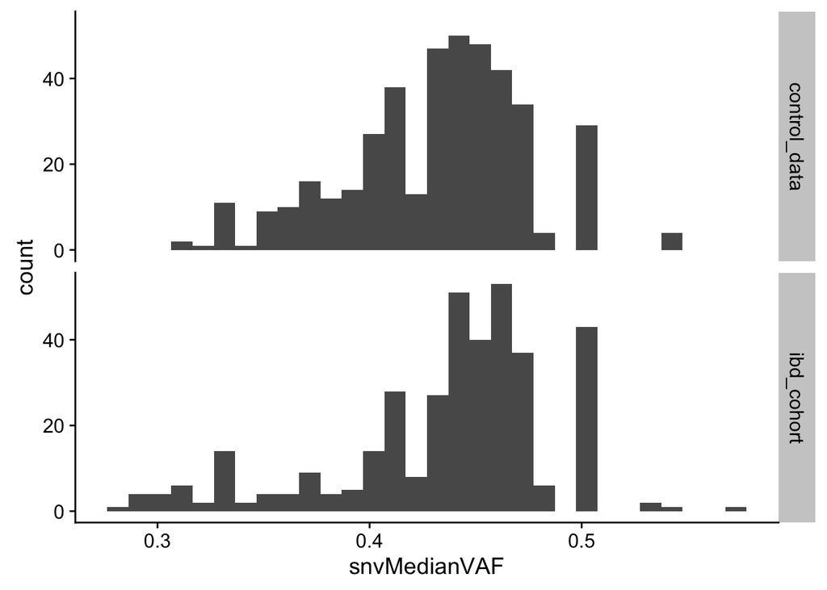

```r
## Compare the VAF distributions and the coverage between the two different cohorts.
ggplot(test_cohort, aes(x=snvMedianVAF)) + geom_histogram() + facet_grid(cohort~.)
```

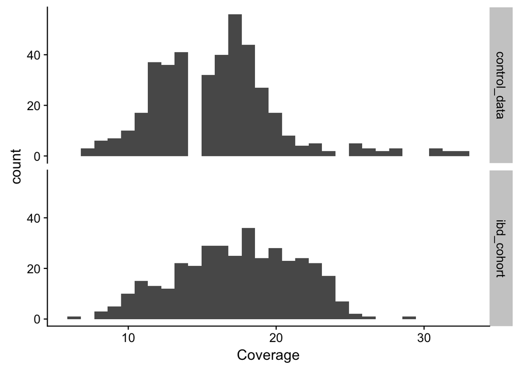

```r
ggplot(test_cohort, aes(x=Coverage)) + geom_histogram() + facet_grid(cohort~.)
```

```r
tapply(test_cohort$snvMedianVAF, test_cohort$cohort, median)
```

```
## control_data   ibd_cohort
##       0.4375       0.4444
```

```r
tapply(test_cohort$Coverage, test_cohort$cohort, median)
```

```
## control_data   ibd_cohort
##     16.00000     17.68069
```

### Confirm that the model residuals are normally distributed

That the standardized residuals are normally distributed is an assumption of the model.

```r
summary(model_null.lme)
```

```
## Linear mixed-effects model fit by maximum likelihood
##  Data: test_cohort
##        AIC      BIC    logLik
##   12018.14 12074.09 -5997.072
##
## Random effects:
##  Formula: ~cohort - 1 | patient_ID
##  Structure: General positive-definite
##                    StdDev    Corr
## cohortcontrol_data  609.5353 chrtc_
## cohortibd_cohort   1003.7140 0
##
##  Formula: ~cohort - 1 | biopsy_ID %in% patient_ID
##  Structure: General positive-definite
##                    StdDev    Corr
## cohortcontrol_data  427.3622 chrtc_
## cohortibd_cohort   1066.4868 0
## Residual            337.4163
##
## Variance function:
##  Structure: Different standard deviations per stratum
##  Formula: ~1 | cohort
##  Parameter estimates:
## control_data   ibd_cohort
##     1.000000     1.079109
## Fixed effects: adj_snv ~ Age + location
##                       Value Std.Error  DF  t-value p-value
## (Intercept)        665.9944  362.1267 582 1.839120  0.0664
## Age                 37.0845    6.0973  84 6.082137  0.0000
## locationRight      234.7999  110.2591 112 2.129528  0.0354
## locationTransverse 263.0412  109.5710 582 2.400647  0.0167
##  Correlation:
##                    (Intr) Age    lctnRg
## Age                -0.950
## locationRight      -0.125 -0.033
## locationTransverse -0.064 -0.084  0.513
##
## Standardized Within-Group Residuals:
##        Min         Q1        Med         Q3        Max
## -3.7431436 -0.4656283 -0.0128983  0.3950256  3.6343683
##
## Number of Observations: 782
## Number of Groups:
##                patient_ID biopsy_ID %in% patient_ID
##                        86                       199
```

```r
intervals(model_null.lme, which = "fixed")
```

```
## Approximate 95% confidence intervals
##
##  Fixed effects:
##                        lower      est.      upper
## (Intercept)        -43.41856 665.99437 1375.40730
## Age                 24.99041  37.08446   49.17852
## locationRight       16.89503 234.79993  452.70483
## locationTransverse  48.38958 263.04115  477.69273
## attr(,"label")
## [1] "Fixed effects:"
```

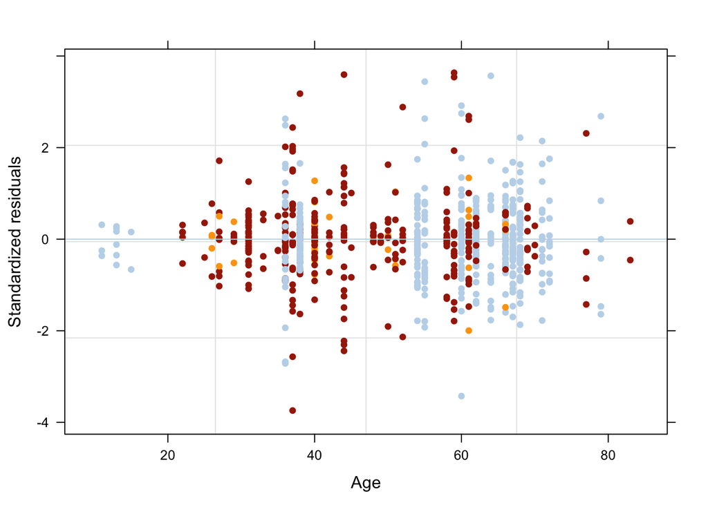

```r
plot(model_null.lme, resid(., type="p") ~ Age, abline = 0, col=test_cohort$colour, pch=20 )
```

## Including disease duration improves the fit of the linear mixed effects model

I will fit the same model as model_null.lme except I add a fixed effect for Disease Duration, that is time since diagnosis plus 6 months. Never inflamed regions from IBD patients have Disease duration set to 0.

```r
model_dur.lme <- lme(fixed = adj_snv ~ Age + location + DiseaseDuration,
                      random = list(patient_ID = pdSymm(form = ~ cohort - 1), biopsy_ID = pdSymm(form = ~ cohort - 1)),
                      weights = varIdent(form= ~ 1 | cohort),
                      data = test_cohort, method="ML")

summary(model_dur.lme)
```

```
## Linear mixed-effects model fit by maximum likelihood
##  Data: test_cohort
##        AIC      BIC    logLik
##   12003.67 12064.27 -5988.834
##
## Random effects:
##  Formula: ~cohort - 1 | patient_ID
##  Structure: General positive-definite
##                    StdDev   Corr
## cohortcontrol_data 585.0458 chrtc_
## cohortibd_cohort   867.0460 0
##
##  Formula: ~cohort - 1 | biopsy_ID %in% patient_ID
##  Structure: General positive-definite
##                    StdDev    Corr
## cohortcontrol_data  426.5965 chrtc_
## cohortibd_cohort   1016.9036 0
## Residual            337.4307
##
## Variance function:
##  Structure: Different standard deviations per stratum
##  Formula: ~1 | cohort
##  Parameter estimates:
## control_data   ibd_cohort
##     1.000000     1.079595
## Fixed effects: adj_snv ~ Age + location + DiseaseDuration
##                        Value Std.Error  DF  t-value p-value
## (Intercept)        310.04823  354.7423 582 0.874010  0.3825
## Age                 40.50978    5.8503  84 6.924382  0.0000
## locationRight      278.37984  109.7586 111 2.536291  0.0126
## locationTransverse 308.53279  109.4509 582 2.818915  0.0050
## DiseaseDuration     48.54669   11.5200 111 4.214114  0.0001
##  Correlation:
##                    (Intr) Age    lctnRg lctnTr
## Age                -0.944
## locationRight      -0.158 -0.013
## locationTransverse -0.097 -0.065  0.516
## DiseaseDuration    -0.271  0.157  0.109  0.115
##
## Standardized Within-Group Residuals:
##         Min          Q1         Med          Q3         Max
## -3.74057057 -0.46510604 -0.02236429  0.39360351  3.62371957
##
## Number of Observations: 782
## Number of Groups:
##                patient_ID biopsy_ID %in% patient_ID
##                        86                       199
```

```r
intervals(model_dur.lme, which = "fixed")
```

```
## Approximate 95% confidence intervals
##
##  Fixed effects:
##                         lower      est.      upper
## (Intercept)        -384.45193 310.04823 1004.54839
## Age                  28.91305  40.50978   52.10651
## locationRight        61.58221 278.37984  495.17747
## locationTransverse   94.25429 308.53279  522.81128
## DiseaseDuration      25.79209  48.54669   71.30129
## attr(,"label")
## [1] "Fixed effects:"
```

```r
anova(model_null.lme,model_dur.lme, test=T)$"p-value"[2]
```

```
## [1] 4.927429e-05
```

The above model does not include Coverage. We can try adding it in and we see that it makes very little difference to the analysis as the effect is very small compared with the effect of age and disease duration.

```r
model_dur_cov.lme <- lme(fixed = adj_snv ~ Age + location +Coverage+ DiseaseDuration,
                      random = list(patient_ID = pdSymm(form = ~ cohort - 1), biopsy_ID = pdSymm(form = ~ cohort - 1)),
                      weights = varIdent(form= ~ 1 | cohort),
                      data = test_cohort, method="ML")

summary(model_dur_cov.lme)
```

```
## Linear mixed-effects model fit by maximum likelihood
##  Data: test_cohort
##        AIC      BIC    logLik
##   11980.33 12045.59 -5976.164
##
## Random effects:
##  Formula: ~cohort - 1 | patient_ID
##  Structure: General positive-definite
##                    StdDev   Corr
## cohortcontrol_data 596.4164 chrtc_
## cohortibd_cohort   814.6728 0
##
##  Formula: ~cohort - 1 | biopsy_ID %in% patient_ID
##  Structure: General positive-definite
##                    StdDev    Corr
## cohortcontrol_data  416.8147 chrtc_
## cohortibd_cohort   1021.3849 0
## Residual            332.8479
##
## Variance function:
##  Structure: Different standard deviations per stratum
##  Formula: ~1 | cohort
##  Parameter estimates:
## control_data   ibd_cohort
##      1.00000      1.06989
## Fixed effects: adj_snv ~ Age + location + Coverage + DiseaseDuration
##                        Value Std.Error  DF   t-value p-value
## (Intercept)        -202.8061  366.4120 581 -0.553492  0.5801
## Age                  41.4114    5.8161  84  7.120181  0.0000
## locationRight       323.9880  108.2050 111  2.994205  0.0034
## locationTransverse  324.8011  107.4389 581  3.023123  0.0026
## Coverage             28.7942    5.6782 581  5.071014  0.0000
## DiseaseDuration      47.3069   11.2594 111  4.201542  0.0001
##  Correlation:
##                    (Intr) Age    lctnRg lctnTr Coverg
## Age                -0.914
## locationRight      -0.176 -0.008
## locationTransverse -0.101 -0.062  0.516
## Coverage           -0.283  0.035  0.087  0.030
## DiseaseDuration    -0.258  0.155  0.105  0.113 -0.018
##
## Standardized Within-Group Residuals:
##         Min          Q1         Med          Q3         Max
## -3.61716780 -0.44490785 -0.01843911  0.40905154  3.65422448
##
## Number of Observations: 782
## Number of Groups:
##                patient_ID biopsy_ID %in% patient_ID
##                        86                       199
```

```r
intervals(model_dur_cov.lme, which = "fixed")
```

```
## Approximate 95% confidence intervals
##
##  Fixed effects:
##                         lower       est.     upper
## (Intercept)        -919.69349 -202.80608 514.08133
## Age                  29.88998   41.41140  52.93281
## locationRight       110.39667  323.98804 537.57941
## locationTransverse  114.59619  324.80110 535.00601
## Coverage             17.68476   28.79417  39.90357
## DiseaseDuration      25.08139   47.30692  69.53245
## attr(,"label")
## [1] "Fixed effects:"
```

```r
anova(model_cov,model_dur_cov.lme, test=T)$"p-value"[2]
```

```
## [1] 5.049918e-05
```

## Plot the model:

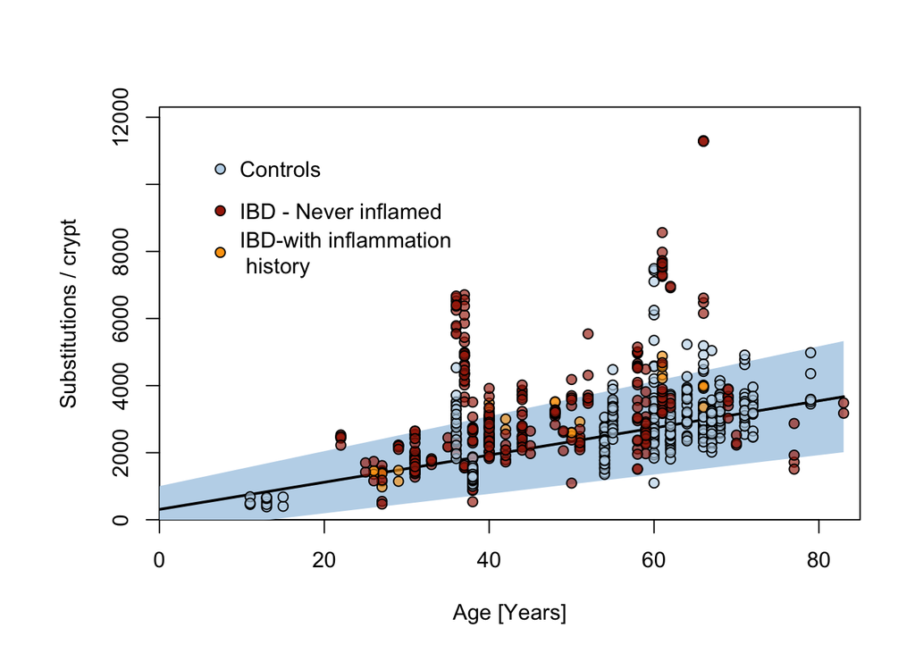

```r
lme.ints <- intervals(model_dur.lme, which="fixed")$fixed
par(mar=c(5.1,6.1,4.1,2.1))
 plot(NULL, xlim=c(0, (max(test_cohort$Age)+2)), ylim=c(0, (max(test_cohort$adj_snv)+1000)),
     xlab="Age [Years]", ylab="Substitutions / crypt", yaxs="i", xaxs="i",cex.lab=1, cex.axis=1)


polygon(x = c(0, max(test_cohort$Age), max(test_cohort$Age), 0),
        y = c(lme.ints["(Intercept)", "lower"],
              lme.ints["(Intercept)", "lower"] + max(test_cohort$Age) * lme.ints["Age", "lower"],
              lme.ints["(Intercept)", "upper"] + max(test_cohort$Age) * lme.ints["Age", "upper"],
              lme.ints["(Intercept)", "upper"]),
        col="#BFD7EA", border=NA)
lines(x = c(0, max(test_cohort$Age)),
      y = c(lme.ints["(Intercept)", "est."],
            lme.ints["(Intercept)", "est."] + max(test_cohort$Age) * lme.ints["Age", "est."]),
      lwd=2)

points(x = test_cohort$Age, y = test_cohort$adj_snv, bg=alpha(test_cohort$colour, 0.65), pch=21, cex=1)

legend(x = 5, y = 11700, col = "black", pch=21 ,pt.bg=unique(test_cohort$colour), bty="n", pt.cex = 1,cex=1,
       legend = c("Controls", "IBD - Never inflamed","IBD-with inflammation \n history"))
```

## Restricted analyses

I want to see how this looks like when I only look at specific restricted sub-types of data.

We do observe that never-inflamed regions from IBD patients have a higher mutation burden than controls. This may reflect that there is some uncertainty in the annotation of the biopsies. It might also mean that the effect of inflammation extends beyond the immediately inflamed sites or it might be batch effect.

We also observe that there is an effect of disease duration within the IBD cohort.

```r
never_infl_only <- subset(test_cohort, type=="Never_Inflamed")

model_ibd_never_infl1 <- lme(fixed = adj_snv ~ Age + location + cohort,
                      random = list(patient_ID = pdSymm(form = ~ cohort - 1), biopsy_ID = pdSymm(form = ~ cohort - 1)),
                      weights = varIdent(form= ~ 1 | cohort),
                      data = never_infl_only, method="ML")

model_ibd_never_infl2 <- lme(fixed = adj_snv ~ Age + location,
                      random = list(patient_ID = pdSymm(form = ~ cohort - 1), biopsy_ID = pdSymm(form = ~ cohort - 1)),
                      weights = varIdent(form= ~ 1 | cohort),
                      data = never_infl_only, method="ML")

anova(model_ibd_never_infl1,model_ibd_never_infl2, test=T)$"p-value"[2]
```

```
## [1] 0.01130537
```

```r
summary(model_ibd_never_infl1)
```

```
## Linear mixed-effects model fit by maximum likelihood
##  Data: never_infl_only
##        AIC      BIC    logLik
##   6818.336 6871.785 -3396.168
##
## Random effects:
##  Formula: ~cohort - 1 | patient_ID
##  Structure: General positive-definite
##                    StdDev   Corr
## cohortcontrol_data 597.2370 chrtc_
## cohortibd_cohort   429.1678 0
##
##  Formula: ~cohort - 1 | biopsy_ID %in% patient_ID
##  Structure: General positive-definite
##                    StdDev   Corr
## cohortcontrol_data 426.5432 chrtc_
## cohortibd_cohort   198.2040 0
## Residual           337.5919
##
## Variance function:
##  Structure: Different standard deviations per stratum
##  Formula: ~1 | cohort
##  Parameter estimates:
## control_data   ibd_cohort
##    1.0000000    0.8246383
## Fixed effects: adj_snv ~ Age + location + cohort
##                        Value Std.Error  DF   t-value p-value
## (Intercept)        -438.7115  394.3275 335 -1.112556  0.2667
## Age                  51.7037    6.2818  49  8.230703  0.0000
## locationRight       375.7725  115.3837  62  3.256720  0.0018
## locationTransverse  352.0511  116.1153  62  3.031909  0.0035
## cohortibd_cohort    618.6390  207.8072  49  2.976986  0.0045
##  Correlation:
##                    (Intr) Age    lctnRg lctnTr
## Age                -0.946
## locationRight      -0.077 -0.093
## locationTransverse -0.073 -0.092  0.596
## cohortibd_cohort   -0.557  0.455 -0.089 -0.101
##
## Standardized Within-Group Residuals:
##         Min          Q1         Med          Q3         Max
## -3.40641598 -0.49744227 -0.06898258  0.49287171  3.54297826
##
## Number of Observations: 451
## Number of Groups:
##                patient_ID biopsy_ID %in% patient_ID
##                        52                       116
```

```r
## Just in the diseased samples, is there an effect of disease duration?
ibd_only <- subset(test_cohort, cohort=="ibd_cohort")
model_ibd_only.lme <- lme(fixed = adj_snv ~ Age + location + DiseaseDuration,
                      random = list(patient_ID = pdSymm(form = ~  1), biopsy_ID = pdSymm(form = ~  1)),
                      weights = varIdent(form= ~ 1 ),
                      data = ibd_only, method="ML")

summary(model_ibd_only.lme)
```

```
## Linear mixed-effects model fit by maximum likelihood
##  Data: ibd_only
##        AIC      BIC    logLik
##   5777.509 5808.817 -2880.755
##
## Random effects:
##  Formula: ~1 | patient_ID
##         (Intercept)
## StdDev:    849.5673
##
##  Formula: ~1 | biopsy_ID %in% patient_ID
##         (Intercept) Residual
## StdDev:    1021.238 363.5163
##
## Fixed effects: adj_snv ~ Age + location + DiseaseDuration
##                       Value Std.Error  DF   t-value p-value
## (Intercept)        666.9615  634.8585 274 1.0505672  0.2944
## Age                 38.6204   12.9915  43 2.9727498  0.0048
## locationRight       83.0680  284.3746  48 0.2921077  0.7715
## locationTransverse  19.9405  257.4219 274 0.0774624  0.9383
## DiseaseDuration     40.3243   15.9731  48 2.5245153  0.0149
##  Correlation:
##                    (Intr) Age    lctnRg lctnTr
## Age                -0.887
## locationRight      -0.370  0.157
## locationTransverse -0.204  0.052  0.314
## DiseaseDuration    -0.071 -0.276  0.157  0.138
##
## Standardized Within-Group Residuals:
##         Min          Q1         Med          Q3         Max
## -3.74971687 -0.37981843 -0.01636108  0.31766885  3.63704665
##
## Number of Observations: 370
## Number of Groups:
##                patient_ID biopsy_ID %in% patient_ID
##                        45                        95
```

## IBD affects the between-patient variance in mutation burden

Next we want to see if the between-patient variance is greater in IBD patients than in the controls. This might be expected as disease severity varies between the patients and patients vary in their response to treatment.

From the analysis below, we conclude that there is significant difference in the between-patient variance but not in the within-patient variance.

```r
model_dur.btwbio.het <- lme(fixed = adj_snv ~ Age + location + DiseaseDuration,
                      random = list(patient_ID = pdSymm(form = ~ 1), biopsy_ID = pdSymm(form = ~cohort-  1)),
                      weights = varIdent(form= ~ 1 | cohort),
                      data = test_cohort, method="ML")

model_dur.btwpt.het <- lme(fixed = adj_snv ~ Age + location + DiseaseDuration,
                      random = list(patient_ID = pdSymm(form = ~ cohort- 1), biopsy_ID = pdSymm(form = ~ 1)),
                      weights = varIdent(form= ~ 1 | cohort),
                      data = test_cohort, method="ML")

anova(model_dur.btwpt.het, model_dur.lme, test=TRUE)$"p-value"[2]
anova(model_dur.btwbio.het, model_dur.lme, test=TRUE)$"p-value"[2]
```

[output not shown]

## Repeat the above analyses for indels

```r
indel_counts <- read.table("/Users/so11/phd/so11_lustre/somatic_ibd_p1/phylogenics/MPBoot/indel/adj_mutCounts/combined_truncBinom_adjusted.txt", h=T)
colnames(indel_counts) <- c("crypt_ID", "adj_indel")

test_cohort <- merge(test_cohort, indel_counts, by="crypt_ID", all.x=T)

## There is an as-yet unidentified problem with patient40. Will sort that out before re-submission...
test_cohort_indel <- subset(test_cohort, !is.na(test_cohort$adj_indel))

model_null.indel <- lme(fixed = adj_indel  ~ Age + location,
                      random = list(patient_ID = pdSymm(form = ~ cohort - 1), biopsy_ID = pdSymm(form = ~ cohort - 1)),
                      weights = varIdent(form= ~ 1 | cohort),
                      data = test_cohort_indel, method="ML")


summary(model_null.indel)
```

```
## Linear mixed-effects model fit by maximum likelihood
##  Data: test_cohort_indel
##       AIC      BIC    logLik
##   8154.27 8209.995 -4065.135
##
## Random effects:
##  Formula: ~cohort - 1 | patient_ID
##  Structure: General positive-definite
##                    StdDev   Corr
## cohortcontrol_data  31.9213 chrtc_
## cohortibd_cohort   120.7869 0
##
##  Formula: ~cohort - 1 | biopsy_ID %in% patient_ID
##  Structure: General positive-definite
##                    StdDev   Corr
## cohortcontrol_data 28.65532 chrtc_
## cohortibd_cohort   91.94279 0
## Residual           27.41614
##
## Variance function:
##  Structure: Different standard deviations per stratum
##  Formula: ~1 | cohort
##  Parameter estimates:
## control_data   ibd_cohort
##     1.000000     1.650234
## Fixed effects: adj_indel ~ Age + location
##                        Value Std.Error  DF   t-value p-value
## (Intercept)         58.23624 25.051995 572  2.324615  0.0204
## Age                  0.79413  0.408835  83  1.942410  0.0555
## locationRight      -18.44566  8.018072 109 -2.300510  0.0233
## locationTransverse  -9.26273  8.220878 109 -1.126732  0.2623
##  Correlation:
##                    (Intr) Age    lctnRg
## Age                -0.953
## locationRight      -0.109 -0.068
## locationTransverse -0.057 -0.114  0.541
##
## Standardized Within-Group Residuals:
##         Min          Q1         Med          Q3         Max
## -5.61265250 -0.36646616  0.01170079  0.37509264  3.77318145
##
## Number of Observations: 768
## Number of Groups:
##                patient_ID biopsy_ID %in% patient_ID
##                        85                       196
```

```r
intervals(model_null.indel, which = "fixed")
```

```
## Approximate 95% confidence intervals
##
##  Fixed effects:
##                           lower        est.      upper
## (Intercept)          9.15941824  58.2362356 107.313053
## Age                 -0.01691068   0.7941258   1.605162
## locationRight      -34.29577627 -18.4456573  -2.595538
## locationTransverse -25.51375309  -9.2627258   6.988301
## attr(,"label")
## [1] "Fixed effects:"
```

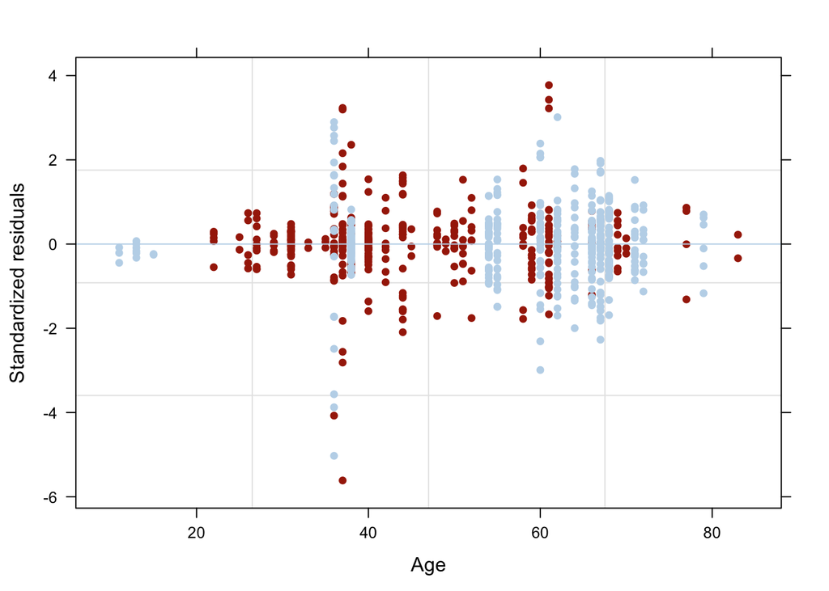

```r
colour.palette.2 <- c("#BFD7EA","#A72608")
names(colour.palette.2) <- c("control_data", "ibd_cohort")
plot(model_null.indel, resid(., type="p") ~ Age, abline = 0, col=colour.palette.2[test_cohort_indel$cohort], pch=20 )
```

```r
model_dur.indel <- lme(fixed = adj_indel ~ Age + location  + DiseaseDuration,
                      random = list(patient_ID = pdSymm(form = ~ cohort - 1), biopsy_ID = pdSymm(form = ~ cohort - 1)),
                      weights = varIdent(form= ~ 1 | cohort),
                      data = test_cohort_indel, method="ML")

summary(model_dur.indel)
```

```
## Linear mixed-effects model fit by maximum likelihood
##  Data: test_cohort_indel
##        AIC      BIC    logLik
##   8121.172 8181.541 -4047.586
##
## Random effects:
##  Formula: ~cohort - 1 | patient_ID
##  Structure: General positive-definite
##                    StdDev   Corr
## cohortcontrol_data 31.44067 chrtc_
## cohortibd_cohort   92.50165 0
##
##  Formula: ~cohort - 1 | biopsy_ID %in% patient_ID
##  Structure: General positive-definite
##                    StdDev   Corr
## cohortcontrol_data 28.25228 chrtc_
## cohortibd_cohort   78.61499 0
## Residual           27.45651
##
## Variance function:
##  Structure: Different standard deviations per stratum
##  Formula: ~1 | cohort
##  Parameter estimates:
## control_data   ibd_cohort
##     1.000000     1.648433
## Fixed effects: adj_indel ~ Age + location + DiseaseDuration
##                        Value Std.Error  DF   t-value p-value
## (Intercept)         33.36739 24.255100 572  1.375686  0.1695
## Age                  1.06319  0.392974  83  2.705502  0.0083
## locationRight      -13.91512  7.868108 108 -1.768547  0.0798
## locationTransverse  -4.75792  8.101476 108 -0.587290  0.5582
## DiseaseDuration      7.20197  1.104643 108  6.519722  0.0000
##  Correlation:
##                    (Intr) Age    lctnRg lctnTr
## Age                -0.950
## locationRight      -0.138 -0.046
## locationTransverse -0.084 -0.095  0.542
## DiseaseDuration    -0.218  0.144  0.106  0.113
##
## Standardized Within-Group Residuals:
##         Min          Q1         Med          Q3         Max
## -5.60587628 -0.37229275  0.01047569  0.36585293  3.77128630
##
## Number of Observations: 768
## Number of Groups:
##                patient_ID biopsy_ID %in% patient_ID
##                        85                       196
```

```r
intervals(model_dur.indel, which = "fixed")
```

```
## Approximate 95% confidence intervals
##
##  Fixed effects:
##                          lower       est.     upper
## (Intercept)        -14.1172005  33.367394 80.851988
## Age                  0.2841311   1.063193  1.842254
## locationRight      -29.4602265 -13.915122  1.629983
## locationTransverse -20.7640870  -4.757916 11.248255
## DiseaseDuration      5.0195119   7.201967  9.384423
## attr(,"label")
## [1] "Fixed effects:"
```

```r
anova(model_null.indel,model_dur.indel, test=T)$"p-value"[2]
```

```
## [1] 3.135222e-09
```

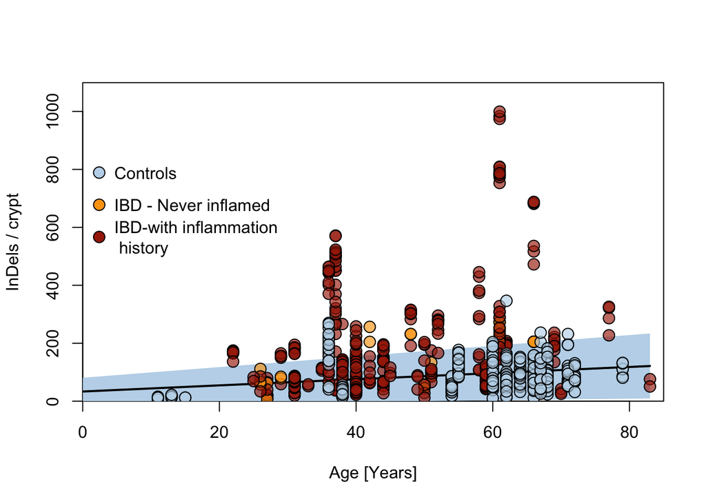

```r
## Plot the model
#######################

lme.ints <- intervals(model_dur.indel, which="fixed")$fixed
plot(NULL, xlim=c(0, (max(test_cohort_indel$Age)+2)), ylim=c(0, (max(test_cohort_indel$adj_indel)+100)),
     xlab="Age [Years]", ylab="InDels / crypt", yaxs="i", xaxs="i")


polygon(x = c(0, max(test_cohort_indel$Age), max(test_cohort_indel$Age), 0),
        y = c(lme.ints["(Intercept)", "lower"],
              lme.ints["(Intercept)", "lower"] + max(test_cohort_indel$Age) * lme.ints["Age", "lower"],
              lme.ints["(Intercept)", "upper"] + max(test_cohort_indel$Age) * lme.ints["Age", "upper"],
              lme.ints["(Intercept)", "upper"]),
        col="#BFD7EA", border=NA)
lines(x = c(0, max(test_cohort_indel$Age)),
      y = c(lme.ints["(Intercept)", "est."],
            lme.ints["(Intercept)", "est."] + max(test_cohort_indel$Age) * lme.ints["Age", "est."]),
      lwd=2)

points(x = test_cohort$Age, y = test_cohort$adj_indel, bg=alpha(test_cohort$colour, 0.65), pch=21, cex=1.5)

legend(x = 0.2, y = 900, col = "black", pch=21 ,pt.bg=unique(test_cohort$colour), bty="n", pt.cex = 1.5,
       legend = c("Controls", "IBD - Never inflamed","IBD-with inflammation \n history"))
```

## Burden of structural variants

```r
cnvs <- read.table("/Users/so11/phd/so11_nfs/somatic_ibd_p1/structural_variation/manual_review/Supplementary_Table4_SV_del_and_dup.txt", h=T)

counts <- data.frame(table(cnvs$crypt_ID))
colnames(counts) <- c("crypt_ID", "SV_count")
test_cohort <- merge(test_cohort, counts, by="crypt_ID", all.x=T)

## If the crypt has no calls in the cnvs file then it should have the count of 0
test_cohort$SV_count[is.na(test_cohort$SV_count)] <- 0

sv_model.null <- glmer(SV_count ~ Age + location + (Age - 1|patient_ID/biopsy_ID), data=test_cohort, family="poisson")
sv_model.dur <- glmer(SV_count ~ Age + location + DiseaseDuration + (Age - 1|patient_ID/biopsy_ID), data=test_cohort, family="poisson")
anova(sv_model.null,sv_model.dur, test=T)$"Pr(>Chisq)"[2]
```

```
## [1] 0.0004674797
```

```r
summary(sv_model.dur)$coefficients
```

```
##                       Estimate Std. Error   z value     Pr(>|z|)
## (Intercept)        -1.71188970 0.69908502 -2.448758 0.0143349919
## Age                -0.04762469 0.01393146 -3.418500 0.0006296722
## locationRight       0.94907124 0.40359945  2.351518 0.0186970021
## locationTransverse  0.81944686 0.46265941  1.771167 0.0765330115
## DiseaseDuration     0.07486923 0.02151455  3.479934 0.0005015371
```

```r
## Get the 95% confidence intervals for the effect estimate.
summary(sv_model.dur)$coefficients[5,1] - 1.96*summary(sv_model.dur)$coefficients[5,2]
```

```
## [1] 0.03270071
```

```r
summary(sv_model.dur)$coefficients[5,1] + 1.96*summary(sv_model.dur)$coefficients[5,2]
```

```
## [1] 0.1170378
```

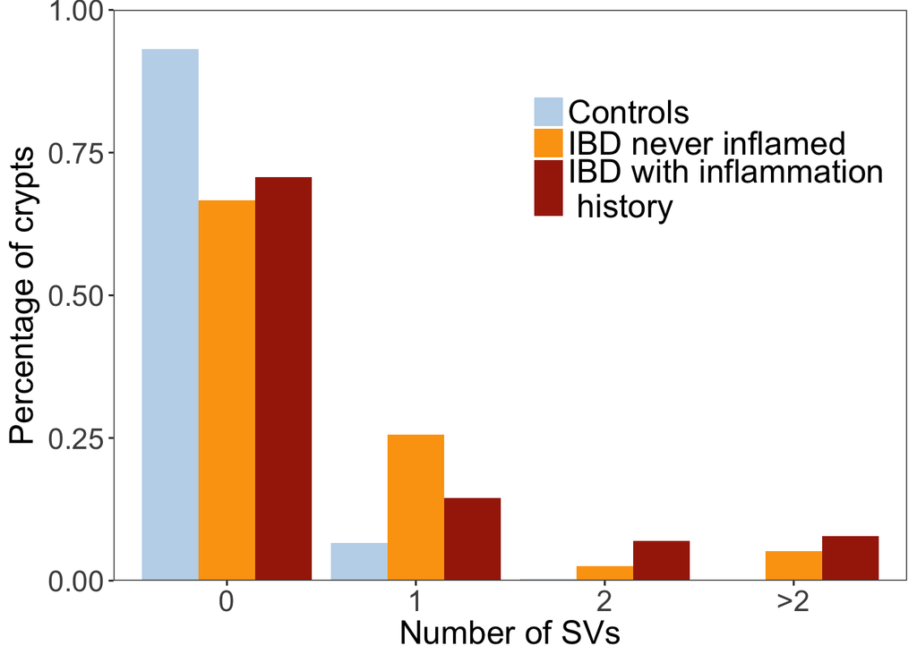

```r
x <- test_cohort
frac_sv_ibd <- c(nrow(x[x$cohort=="ibd_cohort" & x$SV_count==0 & x$type %in% c("Inflamed", "Prev_Inflamed"),])/nrow(x[x$cohort=="ibd_cohort"& x$type %in% c("Inflamed", "Prev_Inflamed"),]),
                 nrow(x[x$cohort=="ibd_cohort" & x$SV_count==1 & x$type %in% c("Inflamed", "Prev_Inflamed"),])/nrow(x[x$cohort=="ibd_cohort"& x$type %in% c("Inflamed", "Prev_Inflamed"),]),
                 nrow(x[x$cohort=="ibd_cohort" & x$SV_count==2 & x$type %in% c("Inflamed", "Prev_Inflamed"),])/nrow(x[x$cohort=="ibd_cohort"& x$type %in% c("Inflamed", "Prev_Inflamed"),]),
                 nrow(x[x$cohort=="ibd_cohort" & x$SV_count>2 & x$type %in% c("Inflamed", "Prev_Inflamed"),])/nrow(x[x$cohort=="ibd_cohort"& x$type %in% c("Inflamed", "Prev_Inflamed"),]))

frac_sv_nevI <- c(nrow(x[x$cohort=="ibd_cohort" & x$SV_count==0 & x$type %in% c("Never_Inflamed"),])/nrow(x[x$cohort=="ibd_cohort"& x$type %in% c("Never_Inflamed"),]),
                  nrow(x[x$cohort=="ibd_cohort" & x$SV_count==1 & x$type %in% c("Never_Inflamed"),])/nrow(x[x$cohort=="ibd_cohort"& x$type %in% c("Never_Inflamed"),]),
                  nrow(x[x$cohort=="ibd_cohort" & x$SV_count==2 & x$type %in% c("Never_Inflamed"),])/nrow(x[x$cohort=="ibd_cohort"& x$type %in% c("Never_Inflamed"),]),
                  nrow(x[x$cohort=="ibd_cohort" & x$SV_count>2 & x$type %in% c("Never_Inflamed"),])/nrow(x[x$cohort=="ibd_cohort"& x$type %in% c("Never_Inflamed"),]))

frac_sv_ctrl <- c(nrow(x[x$cohort=="control_data" & x$SV_count==0 & x$type %in% c("Never_Inflamed"),])/nrow(x[x$cohort=="control_data"& x$type %in% c("Never_Inflamed"),]),
                  nrow(x[x$cohort=="control_data" & x$SV_count==1 & x$type %in% c("Never_Inflamed"),])/nrow(x[x$cohort=="control_data"& x$type %in% c("Never_Inflamed"),]),
                  nrow(x[x$cohort=="control_data" & x$SV_count==2 & x$type %in% c("Never_Inflamed"),])/nrow(x[x$cohort=="control_data"& x$type %in% c("Never_Inflamed"),]),
                  nrow(x[x$cohort=="control_data" & x$SV_count>2 & x$type %in% c("Never_Inflamed"),])/nrow(x[x$cohort=="control_data"& x$type %in% c("Never_Inflamed"),]))


sv_plot_data <- data.frame(SV_count=c("0", "1", "2", ">2"), frac_sv_ctrl,frac_sv_nevI, frac_sv_ibd)
colnames(sv_plot_data) <- c("SV_count", "Controls", "IBD never inflamed", "IBD with inflammation\n history")
sv_plot_data_m <- melt(sv_plot_data)
sv_plot_data_m$SV_count <- factor(sv_plot_data_m$SV_count, levels=c("0", "1", "2", ">2"))

ggplot(sv_plot_data_m, aes(x=SV_count, y=value, fill=variable)) + geom_bar(position = "dodge", stat="identity") +
  labs(y="Percentage of crypts", x="Number of SVs") + theme_bw() + theme(legend.title = element_blank()) +
  theme(panel.grid = element_blank()) + theme(legend.position = c(0.75,0.75)) +
  theme(legend.text = element_text(size=18), axis.text = element_text(size=16), axis.title = element_text(size=18)) +
  scale_y_continuous(expand = c(0,0), limits=c(0,1)) + scale_fill_manual(values = c("#BFD7EA","#FCA311", "#A72608"))
```

## LMM for signature exposure

```r
SignatureExposure <- read.table("/Users/so11/phd/so11_lustre/somatic_ibd_p1/signature_extraction/hdp/snvs/crypt_exposure_mutCounts_post_EM.txt", h=T)

test_cohort <- merge(test_cohort, SignatureExposure, all.x=T)

Suppl_table_2 <- test_cohort[, c("crypt_ID", "patient_ID","Sex","Age","cohort", "Disease", "DiseaseDuration",
                                 "Purine_years","biopsy_ID","location", "type","Coverage",
                                 "snvMedianVAF", "indelMedianVAF","adj_snv", "adj_indel","SV_count",
                                 "Unassigned", "SBS1", "SBS5", "SBSA", "SBS18", "SBS32",
                                 "SBSB", "SBS17b", "SBS35", "SBS13", "SBS2", "SBS17a")]

write.table(Suppl_table_2, "/Users/so11/phd/somatic_ibd_p1/manuscript/Supplementary_material/Supplementary_Table2_crypt_metaData.txt", row.names=F, quote=F)

### Signature 1
##################

model_null.sbs1 <- lme(fixed = SBS1 ~ Age + location,
                      random = list(patient_ID = pdSymm(form = ~ cohort - 1), biopsy_ID = pdSymm(form = ~ cohort - 1)),
                      weights = varIdent(form= ~ 1 | cohort),
                      data = subset(test_cohort, !is.na(SBS1)), method="ML")

summary(model_null.sbs1)
```

```
## Linear mixed-effects model fit by maximum likelihood
##  Data: subset(test_cohort, !is.na(SBS1))
##        AIC      BIC    logLik
##   10061.34 10116.83 -5018.672
##
## Random effects:
##  Formula: ~cohort - 1 | patient_ID
##  Structure: General positive-definite
##                    StdDev   Corr
## cohortcontrol_data 222.7239 chrtc_
## cohortibd_cohort   253.0522 0
##
##  Formula: ~cohort - 1 | biopsy_ID %in% patient_ID
##  Structure: General positive-definite
##                    StdDev   Corr
## cohortcontrol_data 128.1963 chrtc_
## cohortibd_cohort   236.2217 0
## Residual           142.3731
##
## Variance function:
##  Structure: Different standard deviations per stratum
##  Formula: ~1 | cohort
##  Parameter estimates:
## control_data   ibd_cohort
##    1.0000000    0.9524223
## Fixed effects: SBS1 ~ Age + location
##                        Value Std.Error  DF  t-value p-value
## (Intercept)         50.71008 108.30272 558 0.468225  0.6398
## Age                 13.92948   1.88063  83 7.406801  0.0000
## locationRight      212.37905  34.17490 108 6.214476  0.0000
## locationTransverse 185.99540  34.81468 558 5.342441  0.0000
##  Correlation:
##                    (Intr) Age    lctnRg
## Age                -0.945
## locationRight      -0.153 -0.006
## locationTransverse -0.081 -0.065  0.509
##
## Standardized Within-Group Residuals:
##         Min          Q1         Med          Q3         Max
## -3.45589627 -0.49524142 -0.02034705  0.46195874  3.89285719
##
## Number of Observations: 753
## Number of Groups:
##                patient_ID biopsy_ID %in% patient_ID
##                        85                       194
```

```r
model_dur.sbs1 <- lme(fixed = SBS1 ~ Age + location + DiseaseDuration,
                      random = list(patient_ID = pdSymm(form = ~ cohort - 1), biopsy_ID = pdSymm(form = ~ cohort - 1)),
                      weights = varIdent(form= ~ 1 | cohort),
                      data = subset(test_cohort, !is.na(SBS1)), method="ML")

summary(model_dur.sbs1)
```

```
## Linear mixed-effects model fit by maximum likelihood
##  Data: subset(test_cohort, !is.na(SBS1))
##        AIC      BIC   logLik
##   10048.42 10108.53 -5011.21
##
## Random effects:
##  Formula: ~cohort - 1 | patient_ID
##  Structure: General positive-definite
##                    StdDev   Corr
## cohortcontrol_data 209.6564 chrtc_
## cohortibd_cohort   228.4974 0
##
##  Formula: ~cohort - 1 | biopsy_ID %in% patient_ID
##  Structure: General positive-definite
##                    StdDev   Corr
## cohortcontrol_data 127.9736 chrtc_
## cohortibd_cohort   225.2610 0
## Residual           142.3114
##
## Variance function:
##  Structure: Different standard deviations per stratum
##  Formula: ~1 | cohort
##  Parameter estimates:
## control_data   ibd_cohort
##    1.0000000    0.9536976
## Fixed effects: SBS1 ~ Age + location + DiseaseDuration
##                        Value Std.Error  DF   t-value p-value
## (Intercept)        -64.09184 106.24733 558 -0.603232  0.5466
## Age                 14.83399   1.78642  83  8.303731  0.0000
## locationRight      228.22693  34.02147 107  6.708320  0.0000
## locationTransverse 202.27518  34.79882 558  5.812702  0.0000
## DiseaseDuration     11.87697   2.98877 107  3.973865  0.0001
##  Correlation:
##                    (Intr) Age    lctnRg lctnTr
## Age                -0.934
## locationRight      -0.193  0.015
## locationTransverse -0.122 -0.047  0.515
## DiseaseDuration    -0.286  0.131  0.136  0.140
##
## Standardized Within-Group Residuals:
##         Min          Q1         Med          Q3         Max
## -3.46789185 -0.48191760 -0.01682576  0.47824502  3.94831108
##
## Number of Observations: 753
## Number of Groups:
##                patient_ID biopsy_ID %in% patient_ID
##                        85                       194
```

```r
intervals(model_dur.sbs1, which = "fixed")
```

```
## Approximate 95% confidence intervals
##
##  Fixed effects:
##                          lower      est.     upper
## (Intercept)        -272.091428 -64.09184 143.90774
## Age                  11.292680  14.83399  18.37530
## locationRight       161.007618 228.22693 295.44624
## locationTransverse  134.149791 202.27518 270.40056
## DiseaseDuration       5.971785  11.87697  17.78215
## attr(,"label")
## [1] "Fixed effects:"
```

```r
anova(model_null.sbs1,model_dur.sbs1, test=T)$"p-value"[2]
```

```
## [1] 0.0001120291
```

```r
### Signature 5
##################
model_null.sbs5 <- lme(fixed = SBS5 ~ Age + location,
                      random = list(patient_ID = pdSymm(form = ~ cohort - 1), biopsy_ID = pdSymm(form = ~ cohort - 1)),
                      weights = varIdent(form= ~ 1 | cohort),
                      data = subset(test_cohort, !is.na(SBS5)), method="ML")

summary(model_null.sbs5)
```

```
## Linear mixed-effects model fit by maximum likelihood
##  Data: subset(test_cohort, !is.na(SBS5))
##        AIC      BIC    logLik
##   10207.67 10263.16 -5091.835
##
## Random effects:
##  Formula: ~cohort - 1 | patient_ID
##  Structure: General positive-definite
##                    StdDev   Corr
## cohortcontrol_data 203.3188 chrtc_
## cohortibd_cohort   471.7571 0
##
##  Formula: ~cohort - 1 | biopsy_ID %in% patient_ID
##  Structure: General positive-definite
##                    StdDev   Corr
## cohortcontrol_data 164.1663 chrtc_
## cohortibd_cohort   431.3886 0
## Residual           129.8191
##
## Variance function:
##  Structure: Different standard deviations per stratum
##  Formula: ~1 | cohort
##  Parameter estimates:
## control_data   ibd_cohort
##     1.000000     1.226383
## Fixed effects: SBS5 ~ Age + location
##                        Value Std.Error  DF  t-value p-value
## (Intercept)         30.20116 138.55988 558 0.217965  0.8275
## Age                 18.27145   2.29113  83 7.974852  0.0000
## locationRight      166.66720  42.94026 108 3.881374  0.0002
## locationTransverse 161.91061  42.93975 558 3.770647  0.0002
##  Correlation:
##                    (Intr) Age    lctnRg
## Age                -0.952
## locationRight      -0.119 -0.046
## locationTransverse -0.061 -0.096  0.520
##
## Standardized Within-Group Residuals:
##         Min          Q1         Med          Q3         Max
## -4.21143735 -0.47606638 -0.04625082  0.36856919  5.67927855
##
## Number of Observations: 753
## Number of Groups:
##                patient_ID biopsy_ID %in% patient_ID
##                        85                       194
```

```r
model_dur.sbs5 <- lme(fixed = SBS5 ~ Age + location + DiseaseDuration,
                      random = list(patient_ID = pdSymm(form = ~ cohort - 1), biopsy_ID = pdSymm(form = ~ cohort - 1)),
                      weights = varIdent(form= ~ 1 | cohort),
                      data = subset(test_cohort, !is.na(SBS5)), method="ML")

summary(model_dur.sbs5)
```

```
## Linear mixed-effects model fit by maximum likelihood
##  Data: subset(test_cohort, !is.na(SBS5))
##        AIC      BIC    logLik
##   10192.11 10252.22 -5083.054
##
## Random effects:
##  Formula: ~cohort - 1 | patient_ID
##  Structure: General positive-definite
##                    StdDev   Corr
## cohortcontrol_data 191.9821 chrtc_
## cohortibd_cohort   411.3136 0
##
##  Formula: ~cohort - 1 | biopsy_ID %in% patient_ID
##  Structure: General positive-definite
##                    StdDev   Corr
## cohortcontrol_data 165.5989 chrtc_
## cohortibd_cohort   405.4563 0
## Residual           129.7656
##
## Variance function:
##  Structure: Different standard deviations per stratum
##  Formula: ~1 | cohort
##  Parameter estimates:
## control_data   ibd_cohort
##     1.000000     1.227219
## Fixed effects: SBS5 ~ Age + location + DiseaseDuration
##                        Value Std.Error  DF   t-value p-value
## (Intercept)        -86.12070 135.08812 558 -0.637515  0.5241
## Age                 19.42219   2.19979  83  8.829096  0.0000
## locationRight      182.91893  42.97424 107  4.256479  0.0000
## locationTransverse 178.30826  43.11733 558  4.135420  0.0000
## DiseaseDuration     21.55583   4.93945 107  4.364015  0.0000
##  Correlation:
##                    (Intr) Age    lctnRg lctnTr
## Age                -0.948
## locationRight      -0.147 -0.029
## locationTransverse -0.088 -0.081  0.522
## DiseaseDuration    -0.240  0.152  0.096  0.102
##
## Standardized Within-Group Residuals:
##         Min          Q1         Med          Q3         Max
## -4.18112375 -0.47819303 -0.04777231  0.37256751  5.67271125
##
## Number of Observations: 753
## Number of Groups:
##                patient_ID biopsy_ID %in% patient_ID
##                        85                       194
```

```r
intervals(model_dur.sbs5, which = "fixed")
```

```
## Approximate 95% confidence intervals
##
##  Fixed effects:
##                         lower      est.     upper
## (Intercept)        -350.58166 -86.12070 178.34026
## Age                  15.06144  19.42219  23.78294
## locationRight        98.01083 182.91893 267.82704
## locationTransverse   93.89780 178.30826 262.71873
## DiseaseDuration      11.79651  21.55583  31.31515
## attr(,"label")
## [1] "Fixed effects:"
```

```r
anova(model_null.sbs5,model_dur.sbs5, test=T)$"p-value"[2]
```

```
## [1] 2.780889e-05
```

```r
### Signature 18
####################
model_null.sbs18 <- lme(fixed = SBS18 ~ Age + location,
                      random = list(patient_ID = pdSymm(form = ~ cohort - 1), biopsy_ID = pdSymm(form = ~ cohort - 1)),
                      weights = varIdent(form= ~ 1 | cohort),
                      data = subset(test_cohort, !is.na(SBS18)), method="ML")

summary(model_null.sbs18)
```

```
## Linear mixed-effects model fit by maximum likelihood
##  Data: subset(test_cohort, !is.na(SBS18))
##        AIC      BIC    logLik
##   8961.229 9016.717 -4468.614
##
## Random effects:
##  Formula: ~cohort - 1 | patient_ID
##  Structure: General positive-definite
##                    StdDev   Corr
## cohortcontrol_data 126.0908 chrtc_
## cohortibd_cohort   110.8923 0
##
##  Formula: ~cohort - 1 | biopsy_ID %in% patient_ID
##  Structure: General positive-definite
##                    StdDev   Corr
## cohortcontrol_data 51.14175 chrtc_
## cohortibd_cohort   99.34563 0
## Residual           71.67974
##
## Variance function:
##  Structure: Different standard deviations per stratum
##  Formula: ~1 | cohort
##  Parameter estimates:
## control_data   ibd_cohort
##    1.0000000    0.9033074
## Fixed effects: SBS18 ~ Age + location
##                        Value Std.Error  DF  t-value p-value
## (Intercept)         73.10538  51.29806 558 1.425110  0.1547
## Age                  5.17250   0.91512  83 5.652282  0.0000
## locationRight      114.19690  14.83310 108 7.698790  0.0000
## locationTransverse  88.01926  15.19392 558 5.793058  0.0000
##  Correlation:
##                    (Intr) Age    lctnRg
## Age                -0.945
## locationRight      -0.154  0.013
## locationTransverse -0.086 -0.042  0.515
##
## Standardized Within-Group Residuals:
##         Min          Q1         Med          Q3         Max
## -2.92589648 -0.45434588 -0.05045924  0.40318650  8.54773538
##
## Number of Observations: 753
## Number of Groups:
##                patient_ID biopsy_ID %in% patient_ID
##                        85                       194
```

```r
model_dur.sbs18 <- lme(fixed = SBS18 ~ Age + location + DiseaseDuration,
                      random = list(patient_ID = pdSymm(form = ~ cohort - 1), biopsy_ID = pdSymm(form = ~ cohort - 1)),
                      weights = varIdent(form= ~ 1 | cohort),
                      data = subset(test_cohort, !is.na(SBS18)), method="ML")

summary(model_dur.sbs18)
```

```
## Linear mixed-effects model fit by maximum likelihood
##  Data: subset(test_cohort, !is.na(SBS18))
##       AIC      BIC    logLik
##   8946.93 9007.043 -4460.465
##
## Random effects:
##  Formula: ~cohort - 1 | patient_ID
##  Structure: General positive-definite
##                    StdDev    Corr
## cohortcontrol_data 117.61986 chrtc_
## cohortibd_cohort    95.39233 0
##
##  Formula: ~cohort - 1 | biopsy_ID %in% patient_ID
##  Structure: General positive-definite
##                    StdDev   Corr
## cohortcontrol_data 50.90300 chrtc_
## cohortibd_cohort   97.13305 0
## Residual           71.62487
##
## Variance function:
##  Structure: Different standard deviations per stratum
##  Formula: ~1 | cohort
##  Parameter estimates:
## control_data   ibd_cohort
##    1.0000000    0.9045661
## Fixed effects: SBS18 ~ Age + location + DiseaseDuration
##                        Value Std.Error  DF  t-value p-value
## (Intercept)         18.91021  49.20157 558 0.384342  0.7009
## Age                  5.49508   0.84903  83 6.472172  0.0000
## locationRight      121.73453  14.78185 107 8.235406  0.0000
## locationTransverse  95.61016  15.18704 558 6.295509  0.0000
## DiseaseDuration      5.52237   1.31854 107 4.188264  0.0001
##  Correlation:
##                    (Intr) Age    lctnRg lctnTr
## Age                -0.928
## locationRight      -0.197  0.029
## locationTransverse -0.127 -0.029  0.520
## DiseaseDuration    -0.278  0.092  0.136  0.137
##
## Standardized Within-Group Residuals:
##         Min          Q1         Med          Q3         Max
## -2.90902050 -0.46922935 -0.05577912  0.41652536  8.57340061
##
## Number of Observations: 753
## Number of Groups:
##                patient_ID biopsy_ID %in% patient_ID
##                        85                       194
```

```r
intervals(model_dur.sbs18, which = "fixed")
```

```
## Approximate 95% confidence intervals
##
##  Fixed effects:
##                         lower       est.      upper
## (Intercept)        -77.411315  18.910209 115.231733
## Age                  3.812007   5.495082   7.178157
## locationRight       92.528689 121.734528 150.940368
## locationTransverse  65.878606  95.610163 125.341720
## DiseaseDuration      2.917223   5.522373   8.127522
## attr(,"label")
## [1] "Fixed effects:"
```

```r
anova(model_null.sbs18,model_dur.sbs18, test=T)$"p-value"[2]
```

```
## [1] 5.410797e-05
```

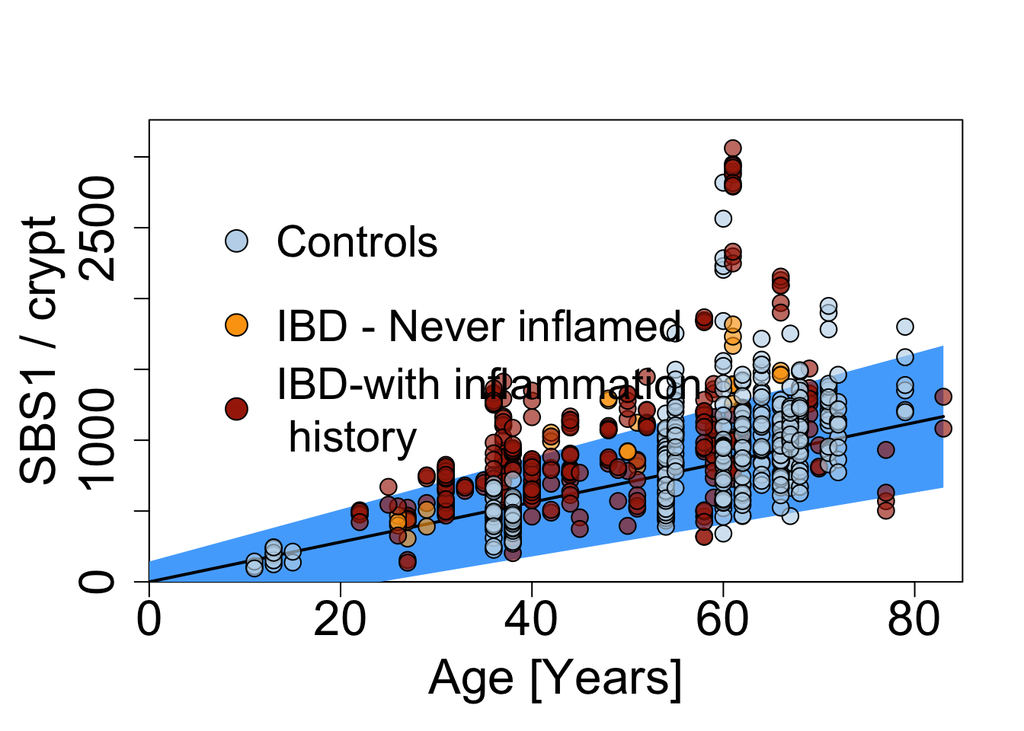

```r
### Plot these models

sig_colours <- c("#F5BB00","#53ADFC","#FCECC9","#067C06", "#DD3B46","#C46BAE", "#0566C6","#B5ABAB",
                 "#F17300", "#A7CECB", "#2D2A32",
                 "#247BA0")

colour.palette.2 <- c("#91B6BF","#A72608")
names(colour.palette.2) <- c("control_data", "ibd_cohort")
lme.ints <- intervals(model_dur.sbs1, which="fixed")$fixed
par(mar=c(5.1,5.1,4.1,2.1))
 plot(NULL, xlim=c(0, (max(test_cohort$Age)+2)), ylim=c(0, (max(test_cohort$SBS1, na.rm=T)+200)),
     xlab="Age [Years]", ylab="SBS1 / crypt", yaxs="i", xaxs="i",cex.lab=2, cex.axis=2)


polygon(x = c(0, max(test_cohort$Age), max(test_cohort$Age), 0),
        y = c(lme.ints["(Intercept)", "lower"],
              lme.ints["(Intercept)", "lower"] + max(test_cohort$Age) * lme.ints["Age", "lower"],
              lme.ints["(Intercept)", "upper"] + max(test_cohort$Age) * lme.ints["Age", "upper"],
              lme.ints["(Intercept)", "upper"]),
        col=sig_colours[2], border=NA)
lines(x = c(0, max(test_cohort$Age)),
      y = c(0,
            lme.ints["(Intercept)", "est."] + max(test_cohort$Age) * lme.ints["Age", "est."]),
      lwd=2)

points(x = test_cohort$Age, y = test_cohort$SBS1, bg=alpha(test_cohort$colour, 0.65), pch=21, cex=1.5)

legend(x = 5, y = 3000, col = "black", pch=21 ,pt.bg=unique(test_cohort$colour), bty="n", pt.cex = 2,cex=1.8,
       legend = c("Controls", "IBD - Never inflamed","IBD-with inflammation \n history"))
```

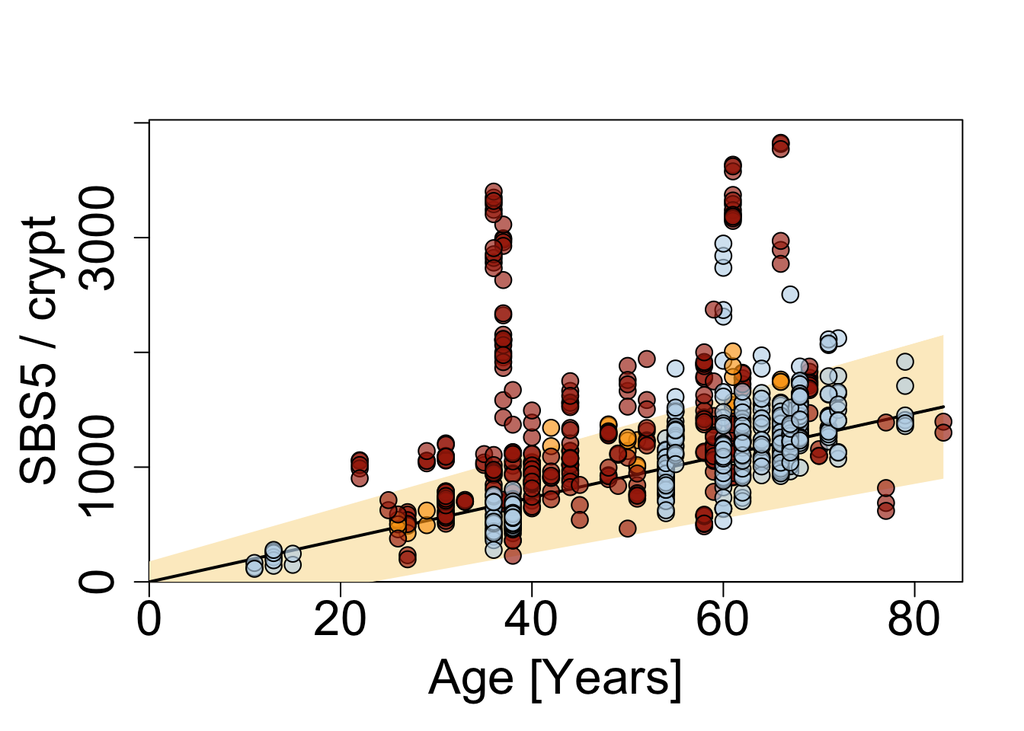

```r
colour.palette.2 <- c("#91B6BF","#A72608")
names(colour.palette.2) <- c("control_data", "ibd_cohort")
lme.ints <- intervals(model_dur.sbs5, which="fixed")$fixed
par(mar=c(5.1,5.1,4.1,2.1))
 plot(NULL, xlim=c(0, (max(test_cohort$Age)+2)), ylim=c(0, (max(test_cohort$SBS5, na.rm=T)+200)),
     xlab="Age [Years]", ylab="SBS5 / crypt", yaxs="i", xaxs="i",cex.lab=2, cex.axis=2)


polygon(x = c(0, max(test_cohort$Age), max(test_cohort$Age), 0),
        y = c(lme.ints["(Intercept)", "lower"],
              lme.ints["(Intercept)", "lower"] + max(test_cohort$Age) * lme.ints["Age", "lower"],
              lme.ints["(Intercept)", "upper"] + max(test_cohort$Age) * lme.ints["Age", "upper"],
              lme.ints["(Intercept)", "upper"]),
        col=sig_colours[3], border=NA)
lines(x = c(0, max(test_cohort$Age)),
      y = c(0,
            lme.ints["(Intercept)", "est."] + max(test_cohort$Age) * lme.ints["Age", "est."]),
      lwd=2)

points(x = test_cohort$Age, y = test_cohort$SBS5, bg=alpha(test_cohort$colour, 0.65), pch=21, cex=1.5)
```

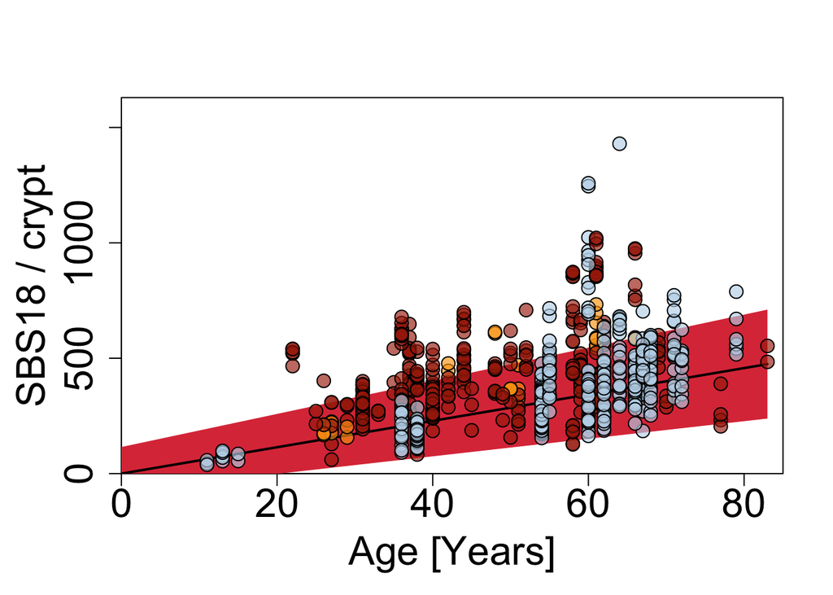

```r
#legend(x = 5, y = 3000, col = "black", pch=21 ,pt.bg=unique(test_cohort$colour), bty="n", pt.cex = 2,cex=1.8,
#       legend = c("Controls", "IBD - Never inflamed","IBD-with inflammation \n history"))




### SBS18
###########

colour.palette.2 <- c("#91B6BF","#A72608")
names(colour.palette.2) <- c("control_data", "ibd_cohort")
lme.ints <- intervals(model_dur.sbs18, which="fixed")$fixed
par(mar=c(5.1,5.1,4.1,2.1))
 plot(NULL, xlim=c(0, (max(test_cohort$Age)+2)), ylim=c(0, (max(test_cohort$SBS18, na.rm=T)+200)),
     xlab="Age [Years]", ylab="SBS18 / crypt", yaxs="i", xaxs="i",cex.lab=2, cex.axis=2)


polygon(x = c(0, max(test_cohort$Age), max(test_cohort$Age), 0),
        y = c(lme.ints["(Intercept)", "lower"],
              lme.ints["(Intercept)", "lower"] + max(test_cohort$Age) * lme.ints["Age", "lower"],
              lme.ints["(Intercept)", "upper"] + max(test_cohort$Age) * lme.ints["Age", "upper"],
              lme.ints["(Intercept)", "upper"]),
        col=sig_colours[5], border=NA)
lines(x = c(0, max(test_cohort$Age)),
      y = c(0,
            lme.ints["(Intercept)", "est."] + max(test_cohort$Age) * lme.ints["Age", "est."]),
      lwd=2)

points(x = test_cohort$Age, y = test_cohort$SBS18, bg=alpha(test_cohort$colour, 0.65), pch=21, cex=1.5)
```

### Differences between CD and UC

I want to find out if there are differences between CD and UC in terms of the mutation burden or eposure to any particular signatures.

```r
ibd_data <- subset(test_cohort, cohort=="ibd_cohort")


## First look into the mutation burden. Add a fixed effect for Disease.
## Allow variance to vary between the two diseases.
model_null.ibd <- lme(fixed = adj_snv ~ Age + location + DiseaseDuration,
                      random = list(patient_ID = pdSymm(form = ~ Disease - 1), biopsy_ID = pdSymm(form = ~ Disease - 1)),
                      weights = varIdent(form= ~ 1 | Disease),
                      data = ibd_data, method="ML")

model_dur.ibd <- lme(fixed = adj_snv ~ Age + location + DiseaseDuration + Disease,
                      random = list(patient_ID = pdSymm(form = ~ Disease - 1), biopsy_ID = pdSymm(form = ~ Disease - 1)),
                      weights = varIdent(form= ~ 1 | Disease),
                      data = ibd_data, method="ML")

summary(model_dur.ibd)
```

```
## Linear mixed-effects model fit by maximum likelihood
##  Data: ibd_data
##        AIC      BIC    logLik
##   5761.589 5816.378 -2866.794
##
## Random effects:
##  Formula: ~Disease - 1 | patient_ID
##  Structure: General positive-definite
##           StdDev   Corr
## DiseaseCD 656.8522 DissCD
## DiseaseUC 916.4052 0
##
##  Formula: ~Disease - 1 | biopsy_ID %in% patient_ID
##  Structure: General positive-definite
##           StdDev    Corr
## DiseaseCD  507.7334 DissCD
## DiseaseUC 1265.3557 0
## Residual   412.7364
##
## Variance function:
##  Structure: Different standard deviations per stratum
##  Formula: ~1 | Disease
##  Parameter estimates:
##        CD        UC
## 1.0000000 0.7935212
## Fixed effects: adj_snv ~ Age + location + DiseaseDuration + Disease
##                       Value Std.Error  DF   t-value p-value
## (Intercept)        494.8582  567.4811 274 0.8720258  0.3840
## Age                 35.8896   11.9072  42 3.0141247  0.0044
## locationRight      213.2819  233.7643  48 0.9123799  0.3661
## locationTransverse  31.9128  209.9653 274 0.1519906  0.8793
## DiseaseDuration     36.8989   13.9439  48 2.6462380  0.0110
## DiseaseUC          448.8292  330.7831  42 1.3568686  0.1821
##  Correlation:
##                    (Intr) Age    lctnRg lctnTr DssDrt
## Age                -0.832
## locationRight      -0.382  0.134
## locationTransverse -0.247  0.061  0.436
## DiseaseDuration    -0.154 -0.266  0.173  0.114
## DiseaseUC          -0.110 -0.218  0.093  0.093  0.243
##
## Standardized Within-Group Residuals:
##        Min         Q1        Med         Q3        Max
## -3.0724484 -0.3875454  0.0106944  0.3209250  3.9903552
##
## Number of Observations: 370
## Number of Groups:
##                patient_ID biopsy_ID %in% patient_ID
##                        45                        95
```

```r
intervals(model_dur.ibd, which = "fixed")
```

```
## Approximate 95% confidence intervals
##
##  Fixed effects:
##                          lower      est.      upper
## (Intercept)        -613.223820 494.85817 1602.94016
## Age                  12.055668  35.88965   59.72363
## locationRight      -252.906263 213.28185  679.46996
## locationTransverse -378.072281  31.91275  441.89779
## DiseaseDuration       9.091046  36.89892   64.70679
## DiseaseUC          -213.283445 448.82922 1110.94189
## attr(,"label")
## [1] "Fixed effects:"
```

```r
anova(model_null.ibd,model_dur.ibd, test=T)$"p-value"[2]
```

```
## [1] 0.1759955
```

```r
model_null.ibd.indel <- lme(fixed = adj_indel ~ Age + location + DiseaseDuration,
                      random = list(patient_ID = pdSymm(form = ~ Disease - 1), biopsy_ID = pdSymm(form = ~ Disease - 1)),
                      weights = varIdent(form= ~ 1 | Disease),
                      data = subset(ibd_data, !is.na(ibd_data$adj_indel)), method="ML")

model_dur.ibd.indel <- lme(fixed = adj_indel ~ Age + location + DiseaseDuration + Disease,
                      random = list(patient_ID = pdSymm(form = ~ Disease - 1), biopsy_ID = pdSymm(form = ~ Disease - 1)),
                      weights = varIdent(form= ~ 1 | Disease),
                      data = subset(ibd_data, !is.na(ibd_data$adj_indel)), method="ML")

summary(model_dur.ibd.indel)
```

```
## Linear mixed-effects model fit by maximum likelihood
##  Data: subset(ibd_data, !is.na(ibd_data$adj_indel))
##        AIC      BIC    logLik
##   4012.947 4067.196 -1992.473
##
## Random effects:
##  Formula: ~Disease - 1 | patient_ID
##  Structure: General positive-definite
##           StdDev    Corr
## DiseaseCD  57.92093 DissCD
## DiseaseUC 107.52084 0
##
##  Formula: ~Disease - 1 | biopsy_ID %in% patient_ID
##  Structure: General positive-definite
##           StdDev   Corr
## DiseaseCD 59.30681 DissCD
## DiseaseUC 85.20125 0
## Residual  48.34134
##
## Variance function:
##  Structure: Different standard deviations per stratum
##  Formula: ~1 | Disease
##  Parameter estimates:
##       CD       UC
## 1.000000 0.897435
## Fixed effects: adj_indel ~ Age + location + DiseaseDuration + Disease
##                       Value Std.Error  DF   t-value p-value
## (Intercept)        24.15883  57.60237 264  0.419407  0.6753
## Age                 0.43736   1.16799  41  0.374455  0.7100
## locationRight      12.31559  24.55977  45  0.501454  0.6185
## locationTransverse -7.56308  28.84659  45 -0.262183  0.7944
## DiseaseDuration     7.11145   1.48955  45  4.774233  0.0000
## DiseaseUC          53.62249  32.33300  41  1.658444  0.1049
##  Correlation:
##                    (Intr) Age    lctnRg lctnTr DssDrt
## Age                -0.820
## locationRight      -0.437  0.138
## locationTransverse -0.322  0.051  0.487
## DiseaseDuration    -0.264 -0.166  0.299  0.273
## DiseaseUC          -0.106 -0.222  0.111  0.139  0.188
##
## Standardized Within-Group Residuals:
##         Min          Q1         Med          Q3         Max
## -5.17245330 -0.30532366  0.03044664  0.31521300  3.89733204
##
## Number of Observations: 356
## Number of Groups:
##                patient_ID biopsy_ID %in% patient_ID
##                        44                        92
```

```r
intervals(model_dur.ibd.indel, which = "fixed")
```

```
## Approximate 95% confidence intervals
##
##  Fixed effects:
##                         lower       est.      upper
## (Intercept)        -88.299843 24.1588316 136.617506
## Age                 -1.901476  0.4373584   2.776193
## locationRight      -36.731709 12.3155899  61.362889
## locationTransverse -65.171406 -7.5630794  50.045247
## DiseaseDuration      4.136734  7.1114482  10.086163
## DiseaseUC          -11.122741 53.6224862 118.367713
## attr(,"label")
## [1] "Fixed effects:"
```

```r
anova(model_null.ibd.indel,model_dur.ibd.indel, test=T)$"p-value"[2]
```

```
## [1] 0.09726483
```

```r
## SVs
sv_model_ibd.null <- glmer(SV_count ~ Age +  DiseaseDuration + (Age - 1|patient_ID/biopsy_ID), data=ibd_data, family="poisson")
sv_model_ibd.dis <- glmer(SV_count ~ Age + DiseaseDuration + Disease + (Age - 1|patient_ID/biopsy_ID), data=ibd_data, family="poisson")

anova(sv_model_ibd.null,sv_model_ibd.dis, test=T)$"Pr(>Chisq)"[2]
```

```
## [1] 0.430828
```

```r
## Next look into the burden of specific signatures
```

So there is no significant difference between CD and UC in terms of the total mutation burden.

I next want to test for a difference in specific signature exposure.

```r
model_null.ibd.sbs1 <- lme(fixed = SBS1 ~ Age + location + DiseaseDuration,
                      random = list(patient_ID = pdSymm(form = ~ Disease - 1), biopsy_ID = pdSymm(form = ~ Disease - 1)),
                      weights = varIdent(form= ~ 1 | Disease),
                      data = subset(ibd_data, !is.na(ibd_data$SBS1)), method="ML")

model_dur.ibd.sbs1 <- lme(fixed = SBS1 ~ Age + location + DiseaseDuration + Disease,
                      random = list(patient_ID = pdSymm(form = ~ Disease - 1), biopsy_ID = pdSymm(form = ~ Disease - 1)),
                      weights = varIdent(form= ~ 1 | Disease),
                      data = subset(ibd_data, !is.na(ibd_data$SBS1)), method="ML")

summary(model_dur.ibd.sbs1)
```

```
## Linear mixed-effects model fit by maximum likelihood
##  Data: subset(ibd_data, !is.na(ibd_data$SBS1))
##       AIC      BIC    logLik
##   4571.99 4625.636 -2271.995
##
## Random effects:
##  Formula: ~Disease - 1 | patient_ID
##  Structure: General positive-definite
##           StdDev    Corr
## DiseaseCD  85.17222 DissCD
## DiseaseUC 266.29533 0
##
##  Formula: ~Disease - 1 | biopsy_ID %in% patient_ID
##  Structure: General positive-definite
##           StdDev   Corr
## DiseaseCD 158.7583 DissCD
## DiseaseUC 250.7767 0
## Residual  151.0178
##
## Variance function:
##  Structure: Different standard deviations per stratum
##  Formula: ~1 | Disease
##  Parameter estimates:
##        CD        UC
## 1.0000000 0.8330248
## Fixed effects: SBS1 ~ Age + location + DiseaseDuration + Disease
##                        Value Std.Error  DF  t-value p-value
## (Intercept)         49.68168 129.19077 250 0.384561  0.7009
## Age                 13.17673   2.70268  41 4.875433  0.0000
## locationRight      126.78462  62.37814  44 2.032517  0.0482
## locationTransverse  67.32002  65.26461 250 1.031493  0.3033
## DiseaseDuration     10.38135   3.14831  44 3.297437  0.0019
## DiseaseUC           98.48123  79.31481  41 1.241650  0.2214
##  Correlation:
##                    (Intr) Age    lctnRg lctnTr DssDrt
## Age                -0.809
## locationRight      -0.424  0.113
## locationTransverse -0.265  0.025  0.397
## DiseaseDuration    -0.150 -0.319  0.201  0.133
## DiseaseUC          -0.119 -0.212  0.135  0.134  0.294
##
## Standardized Within-Group Residuals:
##         Min          Q1         Med          Q3         Max
## -3.81199085 -0.39874989 -0.01023213  0.45441257  2.92719069
##
## Number of Observations: 341
## Number of Groups:
##                patient_ID biopsy_ID %in% patient_ID
##                        44                        90
```

```r
intervals(model_dur.ibd.sbs1, which = "fixed")
```

```
## Approximate 95% confidence intervals
##
##  Fixed effects:
##                          lower      est.     upper
## (Intercept)        -202.510918  49.68168 301.87427
## Age                   7.766791  13.17673  18.58667
## locationRight         2.180635 126.78462 251.38860
## locationTransverse  -60.082675  67.32002 194.72272
## DiseaseDuration       4.092421  10.38135  16.67029
## DiseaseUC           -60.282812  98.48123 257.24528
## attr(,"label")
## [1] "Fixed effects:"
```

```r
anova(model_null.ibd.sbs1,model_dur.ibd.sbs1, test=T)$"p-value"[2]
```

```
## [1] 0.2292185
```

```r
model_null.ibd.sbs5 <- lme(fixed = SBS5 ~ Age + location + DiseaseDuration,
                      random = list(patient_ID = pdSymm(form = ~ Disease - 1), biopsy_ID = pdSymm(form = ~ Disease - 1)),
                      weights = varIdent(form= ~ 1 | Disease),
                      data = subset(ibd_data, !is.na(ibd_data$SBS5)), method="ML")

model_dur.ibd.sbs5 <- lme(fixed = SBS5 ~ Age + location + DiseaseDuration*Disease,
                      random = list(patient_ID = pdSymm(form = ~ Disease - 1), biopsy_ID = pdSymm(form = ~ Disease - 1)),
                      weights = varIdent(form= ~ 1 | Disease),
                      data = subset(ibd_data, !is.na(ibd_data$SBS5)), method="ML")

summary(model_dur.ibd.sbs5)
```

```
## Linear mixed-effects model fit by maximum likelihood
##  Data: subset(ibd_data, !is.na(ibd_data$SBS5))
##        AIC      BIC    logLik
##   4754.447 4811.925 -2362.223
##
## Random effects:
##  Formula: ~Disease - 1 | patient_ID
##  Structure: General positive-definite
##           StdDev   Corr
## DiseaseCD 323.5243 DissCD
## DiseaseUC 425.3087 0
##
##  Formula: ~Disease - 1 | biopsy_ID %in% patient_ID
##  Structure: General positive-definite
##           StdDev   Corr
## DiseaseCD 253.8586 DissCD
## DiseaseUC 471.8318 0
## Residual  188.0254
##
## Variance function:
##  Structure: Different standard deviations per stratum
##  Formula: ~1 | Disease
##  Parameter estimates:
##        CD        UC
## 1.0000000 0.7481569
## Fixed effects: SBS5 ~ Age + location + DiseaseDuration * Disease
##                               Value Std.Error  DF   t-value p-value
## (Intercept)               263.93165 284.20209 250 0.9286760  0.3540
## Age                        11.91426   5.51172  41 2.1616221  0.0365
## locationRight             157.20222 110.74999  43 1.4194333  0.1630
## locationTransverse         94.42164  98.91720 250 0.9545523  0.3407
## DiseaseDuration            15.82518   8.62702  43 1.8343747  0.0735
## DiseaseUC                 122.85455 216.54540  41 0.5673385  0.5736
## DiseaseDuration:DiseaseUC   7.48755  12.73782  43 0.5878207  0.5597
##  Correlation:
##                           (Intr) Age    lctnRg lctnTr DssDrt DissUC
## Age                       -0.788
## locationRight             -0.345  0.144
## locationTransverse        -0.173  0.056  0.407
## DiseaseDuration           -0.333 -0.163  0.074 -0.030
## DiseaseUC                 -0.357 -0.095  0.028 -0.039  0.602
## DiseaseDuration:DiseaseUC  0.341 -0.081  0.058  0.144 -0.638 -0.708
##
## Standardized Within-Group Residuals:
##         Min          Q1         Med          Q3         Max
## -3.06471227 -0.35014652 -0.01878251  0.27442734  4.91585022
##
## Number of Observations: 341
## Number of Groups:
##                patient_ID biopsy_ID %in% patient_ID
##                        44                        90
```

```r
intervals(model_dur.ibd.sbs5, which = "fixed")
```

```
## Approximate 95% confidence intervals
##
##  Fixed effects:
##                                  lower       est.     upper
## (Intercept)               -290.0290280 263.931654 817.89234
## Age                          0.8979536  11.914264  22.93057
## locationRight              -63.8420936 157.202222 378.24654
## locationTransverse         -98.3856716  94.421643 287.22896
## DiseaseDuration             -1.3933581  15.825180  33.04372
## DiseaseUC                 -309.9558309 122.854548 555.66493
## DiseaseDuration:DiseaseUC  -17.9356785   7.487554  32.91079
## attr(,"label")
## [1] "Fixed effects:"
```

```r
anova(model_null.ibd.sbs5,model_dur.ibd.sbs5, test=T)$"p-value"[2]
```

```
## [1] 0.3177919
```

```r
model_null.ibd.sbs18 <- lme(fixed = SBS18 ~ Age + location + DiseaseDuration,
                      random = list(patient_ID = pdSymm(form = ~ Disease - 1), biopsy_ID = pdSymm(form = ~ Disease - 1)),
                      weights = varIdent(form= ~ 1 | Disease),
                      data = subset(ibd_data, !is.na(ibd_data$SBS18)), method="ML")

model_dur.ibd.sbs18 <- lme(fixed = SBS18 ~ Age + location + DiseaseDuration + Disease,
                      random = list(patient_ID = pdSymm(form = ~ Disease - 1), biopsy_ID = pdSymm(form = ~ Disease - 1)),
                      weights = varIdent(form= ~ 1 | Disease),
                      data = subset(ibd_data, !is.na(ibd_data$SBS18)), method="ML")

summary(model_dur.ibd.sbs18)
```

```
## Linear mixed-effects model fit by maximum likelihood
##  Data: subset(ibd_data, !is.na(ibd_data$SBS18))
##        AIC      BIC    logLik
##   4038.869 4092.515 -2005.435
##
## Random effects:
##  Formula: ~Disease - 1 | patient_ID
##  Structure: General positive-definite
##           StdDev       Corr
## DiseaseCD   0.03329093 DissCD
## DiseaseUC 112.91238421 0
##
##  Formula: ~Disease - 1 | biopsy_ID %in% patient_ID
##  Structure: General positive-definite
##           StdDev    Corr
## DiseaseCD  80.84019 DissCD
## DiseaseUC 105.84474 0.001
## Residual   79.10260
##
## Variance function:
##  Structure: Different standard deviations per stratum
##  Formula: ~1 | Disease
##  Parameter estimates:
##        CD        UC
## 1.0000000 0.6928616
## Fixed effects: SBS18 ~ Age + location + DiseaseDuration + Disease
##                       Value Std.Error  DF  t-value p-value
## (Intercept)        71.17157  53.85664 250 1.321500  0.1875
## Age                 4.92242   1.14107  41 4.313856  0.0001
## locationRight      65.25500  27.49353  44 2.373468  0.0221
## locationTransverse 20.68654  29.30170 250 0.705984  0.4809
## DiseaseDuration     5.12703   1.32525  44 3.868728  0.0004
## DiseaseUC          38.74537  33.61873  41 1.152494  0.2558
##  Correlation:
##                    (Intr) Age    lctnRg lctnTr DssDrt
## Age                -0.793
## locationRight      -0.402  0.052
## locationTransverse -0.233 -0.029  0.351
## DiseaseDuration    -0.152 -0.348  0.252  0.165
## DiseaseUC          -0.126 -0.221  0.161  0.152  0.321
##
## Standardized Within-Group Residuals:
##         Min          Q1         Med          Q3         Max
## -3.05210177 -0.45886651 -0.03763698  0.43557627  3.94428656
##
## Number of Observations: 341
## Number of Groups:
##                patient_ID biopsy_ID %in% patient_ID
##                        44                        90
```

```r
intervals(model_dur.ibd.sbs18, which = "fixed")
```

```
## Approximate 95% confidence intervals
##
##  Fixed effects:
##                         lower      est.      upper
## (Intercept)        -33.961691 71.171566 176.304823
## Age                  2.638342  4.922421   7.206499
## locationRight       10.335073 65.254996 120.174919
## locationTransverse -36.513143 20.686541  77.886225
## DiseaseDuration      2.479766  5.127029   7.774292
## DiseaseUC          -28.549056 38.745375 106.039805
## attr(,"label")
## [1] "Fixed effects:"
```

```r
anova(model_null.ibd.sbs18,model_dur.ibd.sbs18, test=T)$"p-value"[2]
```

```
## [1] 0.2542073
```